# Omics Workflow

Bryan Stanfill & Dan Fortin

December 15, 2017

The `pmartRqc` package is used to prepare the metabolite data for analysis. Functions for formatting, filtering, normalizing and summarization are available, as summarized in the following graphic for generic biomolecules, e.g., metabolites, proteins, peptides.

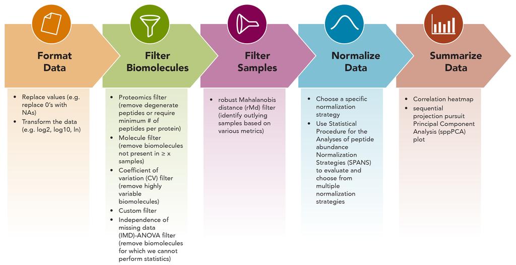

## Format data

Formatting the data consists of two steps. First we group the samples based on the treatments of interest. In this case we’re interested in the “site” and “treatment” variables so each “Group” variable is a combination of those two things. The following Table is the first few lines that maps sample to group.

```r
metab_data <- group_designation(omicsData = metab_data, main_effects = c("site", "treatment"), time_course=NULL)
groups <- groups_orig <-  attr(metab_data, "group_DF")
colnames(groups) <- c("Sample Name","Group","Treatment","Site")
knitr::kable(head(groups))
```

| Sample Name | Group | Treatment | Site |
| --- | --- | --- | --- |
| A_Neg_rep1 | Neg_A | Neg | A |
| A_Neg_rep2 | Neg_A | Neg | A |
| A_Neg_rep3 | Neg_A | Neg | A |
| A_Plus_rep1 | Plus_A | Plus | A |
| A_Plus_rep2 | Plus_A | Plus | A |
| A_Plus_rep3 | Plus_A | Plus | A |

We then consider different transformations of the data. The following histograms summarize the metabolite abundance distributions on different scales for the first replicate of a sample take from site A without the glycine treatment. In this scenario we proceed with the log base two transformed data. Additionally, metabolites that have an observed abundance of zero are replaced with `NA`.

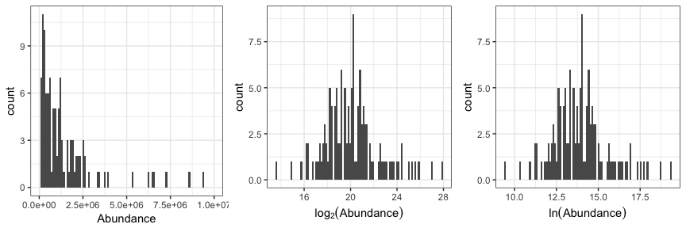

```r
sampi <- metab_data$e_data[,"A_Neg_rep1"]
raw_hist <- qplot(sampi,bins=100)+xlim(c(0,1e7))+xlab("Abundance")+theme_bw()
trans_l2 <- qplot(log2(sampi),bins=100)+xlab(expression(log[2](Abundance)))+theme_bw()
trans_l <- qplot(log(sampi),bins=100)+xlab(expression(ln(Abundance)))+theme_bw()
gridExtra::grid.arrange(raw_hist,trans_l2,trans_l,nrow=1)
```

```r
#The function `edata_transform` will transform the data to the scale of interest
metab_data <- edata_transform(omicsData =  metab_data, data_scale = "log2")
```

With the data transformed to the log base two scale, we now would like to see how the abundance distributions vary across samples. To do this, box plots of abundance distributions for each sample are plotted.

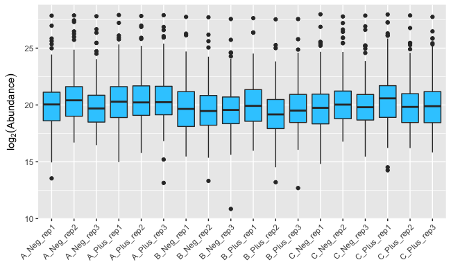

```r
bplot_df <- reshape2::melt(metab_data$e_data[,-1])
qplot(variable,value,geom='boxplot',data=bplot_df,fill=I('#33CCFF'))+xlab("")+ylab(expression(log[2](Abundance)))+
  theme(axis.text.x=element_text(angle=45,hjust = 1))
```

```r
rm(bplot_df)
```

## Filtering

Next, metabolites that don’t meet certain criteria are filtered, i.e, removed from the dataset. Several types of filters are available and their use depends on the scientific question of interest and future analysis plans. The filtering methods available in the `pmartRqc` package are

- Degenerate biomolecule
- Coefficient of variation
- [IMD-ANOVA filter](https://www.ncbi.nlm.nih.gov/pubmed/20831241)
- Custom filters

Because we’ll be using IMD-ANOVA to test for differential abundance of metabolites across samples, we use the IMD-ANOVA filter, which performs both ANOVA and IMD filters. The ANOVA filter removes metabolites that don’t have at least two observations per group, i.e., the minimum number of observations needed to estimate a variance. The IMD filter removes metabolites that don’t have at least three observations within one group, which is a good rule of thumb as the “theoretical number of observations of a metabolite that any single group must have to be significant in the absence of observations in any of the remaining groups” ([Webb-Robertson et al. 2010](http://pubs.acs.org/doi/abs/10.1021/pr1005247) first paragraph, page 4). For this dataset, no metabolites were filtered out.

```r
imd_afilt <- imdanova_filter(omicsData = metab_data)
metab_data <- MSomics_filter(filter_object = imd_afilt, omicsData = metab_data, min_nonmiss_anova = 2,min_nonmiss_gtest = 3)
#attr(metab_data,"filters")
```

Once specific metabolites are filtered out, samples can be filtered out as well. Typically, samples are only filtered out if they are believed to be of suspicious quality. [rMD-PAV](http://bioinformatics.oxfordjournals.org/content/27/20/2866.short) is the only sample filter currently available in the `pmartRqc` package. rMD-PAV uses each sample’s abundance distribution to assess which samples may be outliers. The rMD-PAV scores can be compared to a $\chi^2$ distribution to produce $p$-values associated with the null hypothesis that each sample “fits in” with the rest of the data versus the alternative that that sample is an outlier.

```r
rmd_filter_res <- rmd_filter(omicsData = metab_data)
metab_data <- MSomics_filter(filter_object = rmd_filter_res, omicsData = metab_data, pvalue_threshold = 0.0001)
to_remove <- attr(metab_data,"filters")$rmdFilt$filtered
```

In this example, the third replicate in the glycine negative group at site B (B_Neg_rep3) was filtered out because it returned a $p$-value less than the specified threshold, 0.0001. The four metrics used to determine outlyingness are plotted below, the red point is the sample that was deemed to be an outlier.

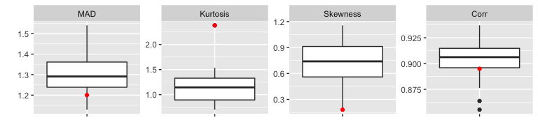

```r
rmd_stats <- rmd_filter_res[,c("sampleID","MAD","Kurtosis","Skewness","Corr")]
rmd_melt <- reshape2::melt(rmd_stats,id.vars=c("sampleID"))
bad_egg <- dplyr::filter(rmd_melt,sampleID==to_remove)
qplot(NA,value,data=rmd_melt,geom='boxplot')+facet_wrap(~variable,scales='free',nrow=1)+
  geom_point(aes(NA,value),colour=2,data=bad_egg)+xlab("")+theme(axis.text.x=element_blank())+ylab("")
```

## Normalize data

After the data are group, transformed and filtered, they are normalized in order to account for systematic bias due to experimentation, sample preparation and instrumentation ([Callister et al. 2006](http://pubs.acs.org/doi/abs/10.1021/pr050300l)). Side note of potential interest to iPASS, see [Bell et al. (2010)](http://bmcbioinformatics.biomedcentral.com/articles/10.1186/1471-2105-13-10) for a new normalization technique pointed to metabolites in general and applied to an experiment with *Arabidopsis thaliana*. Here we used median centering to normalize the metabolite abundance data. That is, the median abundance for each sample is subtracted from the observed abundances such that the result abundance distribution for each sample has a median value of 0.

```r
median_center <- function(e_data, edata_id, feature_subset, backtransform=FALSE){
  subset.data <- e_data[as.character(e_data[,edata_id]) %in% as.character(feature_subset),]
  subset.data <- subset.data[, -which(colnames(subset.data)==edata_id)]
  subset.data <- as.matrix(subset.data)
  # get medians per sample to use for normalization
  location_param <- apply(subset.data, 2, median, na.rm=TRUE)
  scale_param <- NULL
  # normalize
  med.diff <- e_data[,-which(colnames(e_data)==edata_id)] - matrix(rep(location_param, each=nrow(e_data)), nrow=nrow(e_data))
  # if backtransforming, subtract subset median from each sample (updated  by KS 9/29/15)
  if(backtransform==TRUE){
    med.diff <- med.diff + array(median(subset.data, na.rm=TRUE), dim=dim(e_data[,-1]))
  }
  norm_data <- data.frame(e_data[,edata_id], med.diff)
  names(norm_data)[1] <- edata_id
  return(list(norm_data=norm_data, location_param=location_param, scale_param=scale_param))
}
norm_e_data <- median_center(e_data = metab_data$e_data, edata_id="Metabolite",feature_subset = metab_data$e_data$Metabolite)
metab_data$e_data <- norm_e_data$norm_data
attr(metab_data,"data_info")$norm_method <- "median_center"
attr(metab_data,"data_info")$location_param <- norm_e_data$location_param
attr(metab_data,"data_info")$scale_param <- norm_e_data$scale_param
```

## Summarize data

The final functionality of `pmartRqc` is summarization. A quick tabular summary of the final product gives a few statistics that are often of interest. In particular the number of samples, metabolites, missing observations and the proportion of missing observations.

```r
attr(metab_data,"data_info")$num_emeta <- 0
summary(metab_data)
```

```
Summary of 'metabData' Object
---------------------------
Unique sampleIDs (f_data)      17
Unique Metabolites (e_data)   126
Rows (e_meta)                   0
Missing Observations            3
Proportion Missing          0.001
```

To summarize the data visually, one can create a correlation heatmap to identify which samples are highly correlated. Also, a probabilistic principal component plot, which can be used to identify how the data groups naturally. In this example, the data group in the $x$-axis by site, indicating that the site variable is the single most influential variable in the data. There is no clear pattern in the $y$ direction.

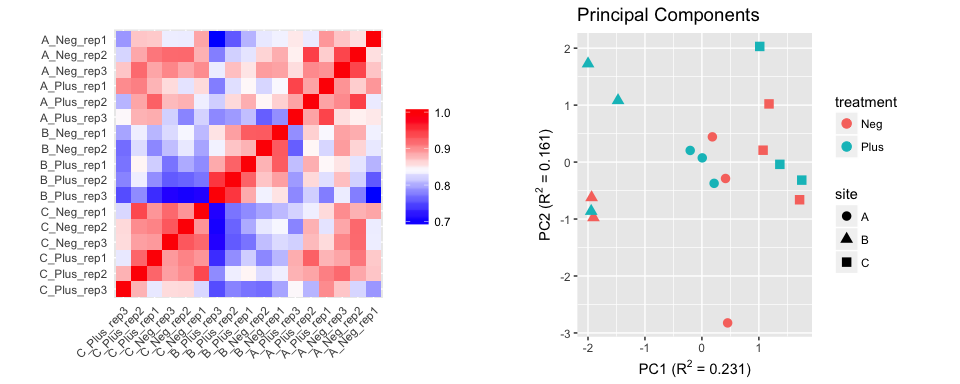

```r
d_for_cor <- cor_result(metab_data)
corr_plot <- plot(d_for_cor)+coord_fixed()+theme(legend.title=element_blank(),axis.text.x=element_text(angle=45,hjust = 1))+
  ggtitle("")
d_for_pp <- dim_reduction(metab_data,k=10)
pp_plot <- plot(d_for_pp)+coord_fixed()+geom_point(size=3,aes(colour=treatment,shape=site))
gridExtra::grid.arrange(corr_plot,pp_plot,nrow=1)
```

## Analyze data

To test for differential abundance between groups we use the IMD-ANOVA test. The independence of missing data (IMD) test assess if there is a *qualitative* difference between groups. In particular, the IMD test answers the question: are the data missing at the same rate across all groups? An analysis of variance (ANOVA) will test for quantitative differences between the groups. The package `pmartRstat` includes functions to implement IMD-ANOVA that allows for covariates, groupings and other effects.

**Test 1: Does glycine addition affect metabolite profiles?**

To test for differences in treatments (positive versus negative for glycine) while controlling for differences due to different sites, the “site” variable is treated as a covariate. Differences in abundance values between treatments is tested for after controlling for variability due to sites.

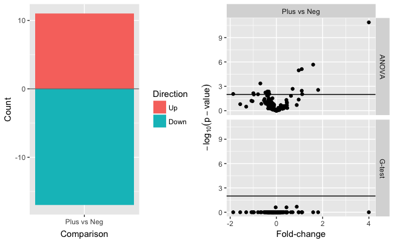

```r
library(MSomicsSTAT)
metab_data <- group_designation(omicsData = metab_data, main_effects = c("treatment"), time_course=NULL)
cov_df <- metab_data$f_data[,c("sampleID","site")]
def_comp <- data.frame(Control="Neg",Test="Plus")
all_groups <- imd_anova(metab_data,test_method = "comb",covariates = cov_df,comparisons = def_comp)
plot(all_groups,plot_type = c("bar","volcano"),fc_threshold = 2)
```

**Test 2: Do metabolite profiles vary by site?**

This test is similar to the above, but treats site as the grouping factor of interest and glycine presence/absence as a covariate. Thus, differences due to site variability are tested for while controlling for differences due to the glycine treatment.

The same plots that were created for Test 1 are created here as well.

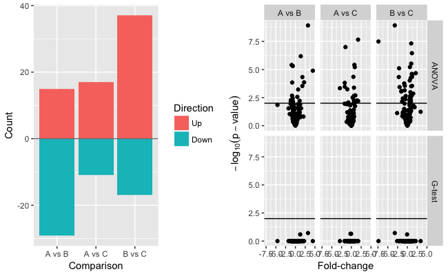

```r
metab_data <- group_designation(omicsData = metab_data, main_effects = c("site"), time_course=NULL)
cov_df <- metab_data$f_data[,c("sampleID","treatment")]
all_groups <- imd_anova(metab_data,test_method = "comb",covariates = cov_df)
plot(all_groups,plot_type = c("bar","volcano"),fc_threshold = 2)
```

```r
metab_data <- group_designation(omicsData = metab_data, main_effects = c("site","treatment"), time_course=NULL)
def_comp <- data.frame(Control=c("Neg","A","A","B"),Test=c("Plus","B","C","C"))
all_groups <- imd_anova(metab_data,test_method = "anova",comparisons = def_comp)
plot(all_groups,plot_type = c("bar","volcano"),fc_threshold = 2)
```

[output not shown]